# Poisson and Exponential distribution

HaiyanJiang

2018年5月9日

用 R 生成随机数，得到概率与quantile 的函数一直弄混。可以先从 `norm` 来看，然后类比得到 `poisson` 的。

```
dnorm(x, mean = 0, sd = 1, log = FALSE)
pnorm(q, mean = 0, sd = 1, lower.tail = TRUE, log.p = FALSE)
qnorm(p, mean = 0, sd = 1, lower.tail = TRUE, log.p = FALSE)
rnorm(n, mean = 0, sd = 1)
```

- 生成4个 norm(0, 1) 的随机数

```r
rnorm(4, mean = 0, sd = 1)
```

```
## [1] 1.5385659 0.6726231 2.1471133 1.8670397
```

- 得到给定概率下的 `quantile`

数值分布在 $(\mu - \sigma, \mu + \sigma)$ 中的概率为 0.6827 数值分布在 $(\mu - 2 \sigma, \mu + 2 \sigma)$ 中的概率为 0.9545 数值分布在 $(\mu - 3 \sigma, \mu + 3 \sigma)$ 中的概率为 0.9973

```r
p1 <- 1 - (1 - 0.6827) / 2
p2 <- 1 - (1 - 0.9545) /2
p3 <- 1 - (1 - 0.9973) /2

c(qnorm(p1),  # u + sigma
qnorm(p2),  # u + 2sigma
qnorm(p3)  # u + 3sigma
)
```

```
## [1] 1.000022 2.000002 2.999977
```

- `dnorm` gives the density, it is the pdf, `pnorm` gives the distribution function, $Pr(X <= x_0)$.

```r
# dnorm(x, mean = 0, sd = 1, log = FALSE)
# pnorm(q, mean = 0, sd = 1, lower.tail = TRUE, log.p = FALSE)
# x, q vector of quantiles.

c(dnorm(0),  # gives the density, it is the pdf
pnorm(2),  # gives the distribution function, Pr(X <= x0)
pnorm(0),
qnorm(1 - 0.05)  # u + 3sigma
)
```

```
## [1] 0.3989423 0.9772499 0.5000000 1.6448536
```

同理，关于 Poisson 的分布函数也可以求得。

```
dpois(x, lambda, log = FALSE)
ppois(q, lambda, lower.tail = TRUE, log.p = FALSE)
qpois(p, lambda, lower.tail = TRUE, log.p = FALSE)
rpois(n, lambda)
```

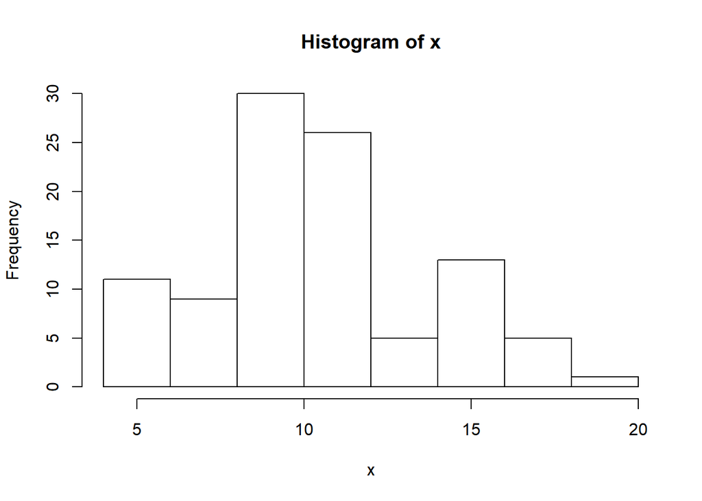

```r
n <- 100
lambda <- 10
x <- rpois(n, lambda)
hist(x)
```

```r
dpois(0, lambda)
```

```
## [1] 4.539993e-05
```

```r
1 - exp(-1/59.6 * 72)
```

```
## [1] 0.7012218
```

```r
1 - exp(-0.0168 * 72)
```

```
## [1] 0.7016834
```

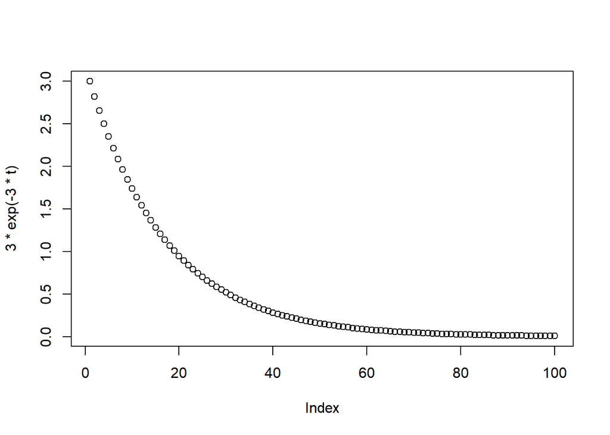

```r
t = seq(0, 2, length.out=100)

plot(3 *exp(-3 *t))
```

```r
ppois(2, lambda, log.p = TRUE)
```

```
## [1] -5.889126
```

```r
rpois(n, lambda)
```

```
##   [1] 11 10  4 10 17 11  8 15 10 10 12  7  6 10 10 11 13 12  6 12  9  8  8
##  [24]  6  9  9  4 11 10  5 10 11 16  9  7  5 18 10  9 11 15 11 15  9 13  7
##  [47]  6 17 13 15 16 12 16 10  8  8 15  7  9 17 13  7 12  4  4  9 12  8 12
##  [70] 10  8  7 13 12 12 12  7 11  8  2  6 12 11 13 13 13 15 14  8 16  9  9
##  [93] 12  8 12 12 11 10  9  6
```

举个国足的例子(网上看到的，很喜欢这个例子)，假设国足参加了2018年世界杯，国足面对世界强队比赛，平均5场比赛进一个球，即单位分钟时间内发生进球事件的次数为 $\lambda = \frac{1}{5 *90} = 0.002222222$。 那么小组赛3场比赛，至少能进一个球的概率是多少？ 3场小组赛，$3*90 = 270$。

$$\Pr(X \leq 270) = \int_{0}^{270} \lambda e ^{-\lambda t} dt
= 1 - e ^{-\lambda t} = 0.4512$$
也就是说3场小组赛一个球不进的概率是 $1-0.4512=54.88\%$.

```r
1 - exp(- 1/ (5 * 90) * 270)
```

```
## [1] 0.4511884
```